# Tugas Pertemuan 7

Muhammad Nafiz

2023-10-16

## Import packages yang dibutuhkan

```r
library(ggplot2)
library(tsibble)
library(tseries)
library(MASS)
library(forecast)
library(TSA)
library(TTR)
library(aTSA)
library(graphics)
```

## import data dan melakukan plot data time series

### data memiliki trend sehingga tidak stasioner dalam rataan

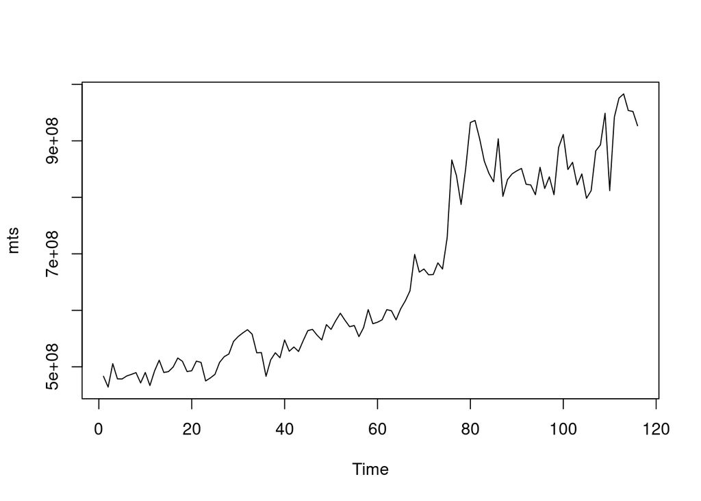

```r
df <- read.csv("https://raw.githubusercontent.com/MNafiz/MPDW/main/ambilData/hasilScrap.csv")
mts <- ts(df$Harga)
ts.plot(mts)
```

## Melakukan splitting data train dan test dengan proporsi 90 : 26

```r
mts_train <- mts[1:90]
mts_test <- mts[91:116]
```

## Pada plot data train, data cenderung tidak stasioner dalam rataan

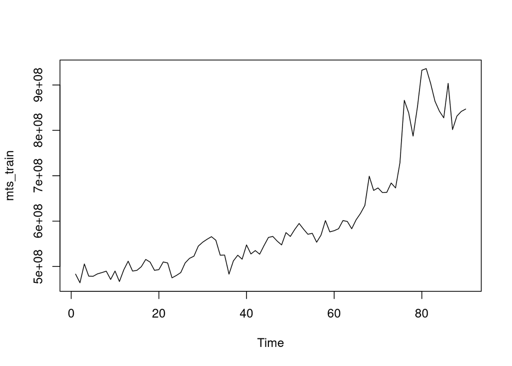

```r
ts.plot(mts_train)
```

## Berdasarkan uji adf, p-value lebih besar dari 5% yang artinya data tidak stasioner dalam rataan

```r
tseries::adf.test(mts_train)
```

```
##
##  Augmented Dickey-Fuller Test
##
## data:  mts_train
## Dickey-Fuller = -1.7109, Lag order = 4, p-value = 0.6952
## alternative hypothesis: stationary
```

## Menggunakan transformasi boxcox, didapatkan dalam interval 95 % nilai lambda tidak mengandung angka 1 yang artinya data juga tidak stasioner dalam ragam

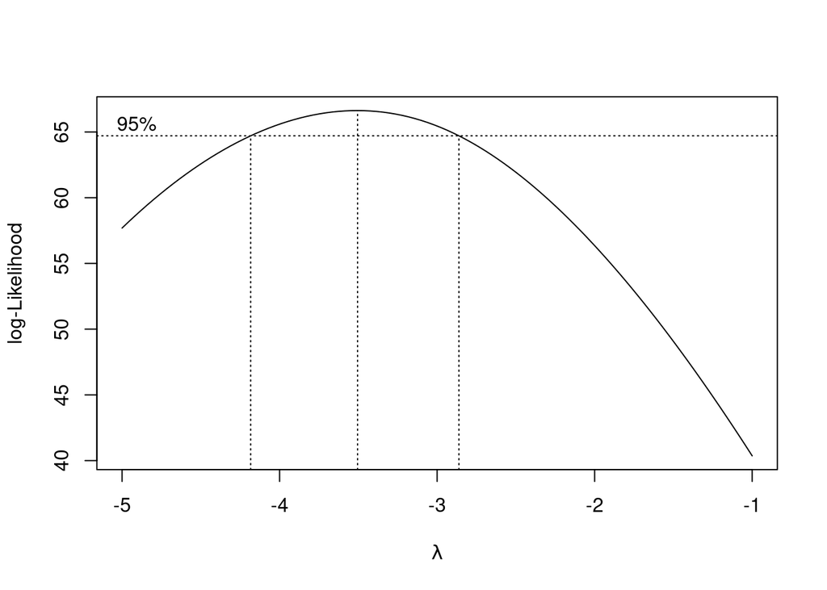

```r
index <- seq(1:90)
bc = boxcox(mts_train~index, lambda = seq(-5,-1,by=1))
```

```r
#Nilai Rounded Lambda
lambda <- bc$x[which.max(bc$y)]
lambda
```

```
## [1] -3.505051
```

```r
#SK
bc$x[bc$y > max(bc$y) - 1/2 * qchisq(.95,1)]
```

```
##  [1] -4.151515 -4.111111 -4.070707 -4.030303 -3.989899 -3.949495 -3.909091
##  [8] -3.868687 -3.828283 -3.787879 -3.747475 -3.707071 -3.666667 -3.626263
## [15] -3.585859 -3.545455 -3.505051 -3.464646 -3.424242 -3.383838 -3.343434
## [22] -3.303030 -3.262626 -3.222222 -3.181818 -3.141414 -3.101010 -3.060606
## [29] -3.020202 -2.979798 -2.939394 -2.898990
```

## Melakukan differencing untuk menanganin ketidakstasioneran dalam rataan

```r
mts_train_diff <- diff(mts_train, differences = 1)
```

## Plot data differencing

### Terlihat data sudah mulai stasioner dalam rataan

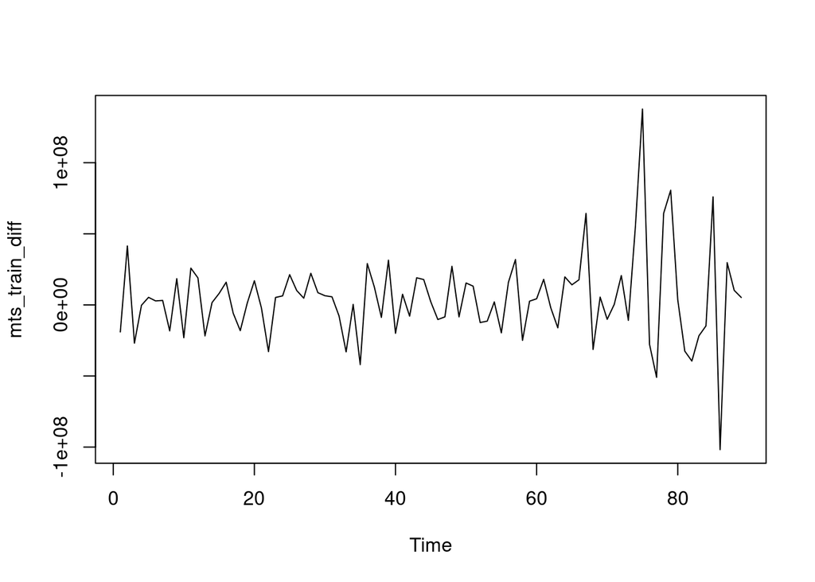

```r
ts.plot(mts_train_diff)
```

## Dengan menggunakan uji adf, p-value kurang dari 5 % sehingga data differencing sudah stasioner dalam rataan

```r
tseries::adf.test(mts_train_diff)
```

```
##
##  Augmented Dickey-Fuller Test
##
## data:  mts_train_diff
## Dickey-Fuller = -3.8621, Lag order = 4, p-value = 0.01959
## alternative hypothesis: stationary
```

## Plot ACF

### Pada plot acf, tidak ada lag yang signifikan sehingga tidak mendapatkan model tentatif

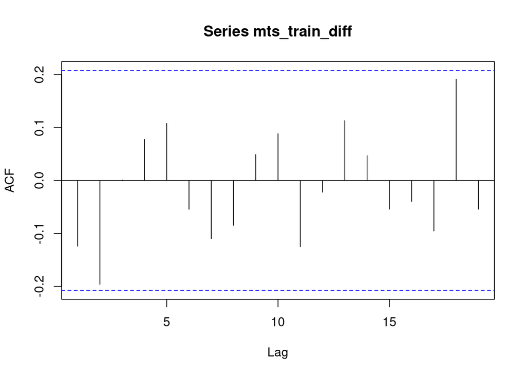

```r
acf(mts_train_diff)
```

## Plot PACF

### Pada plot pacf, lag signifikan pada lag ke 2 sehingga model tentatifnya adalah Arima(2, 1, 0)

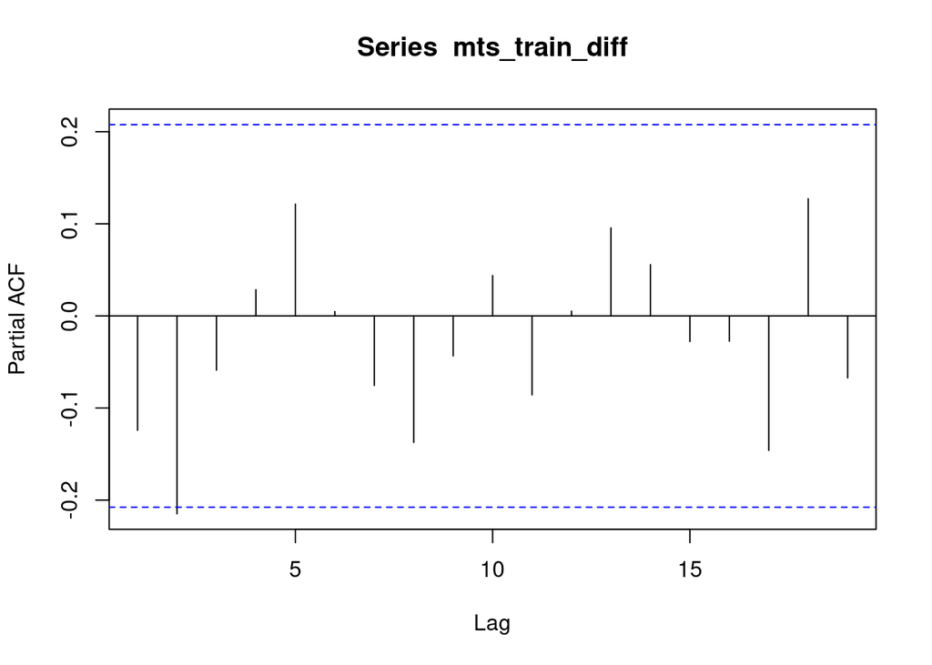

```r
pacf(mts_train_diff)
```

## Plot EACF ### Pada plot eacf, didapatkan model tentatif nya adalah Arima(2, 1, 2) dan Arima(1, 1, 1)

```r
eacf(mts_train_diff)
```

```
## AR/MA
##   0 1 2 3 4 5 6 7 8 9 10 11 12 13
## 0 o o o o o o o o o o o  o  o  o
## 1 x o o o o o o o o o o  o  o  o
## 2 x x o o o o o o o o o  o  o  o
## 3 x o x o o o o o o o o  o  o  o
## 4 x x x o o o o o o o o  o  o  o
## 5 o x x o x o o o o o o  o  o  o
## 6 x o x o o o o o o o o  o  o  o
## 7 x o x o o o o o o o o  o  o  o
```

### Identifikasi Model berdasarkan ACF tidak ada yang signifikan

### Identifikasi Model berdasarkan PACF hanya Arima(2, 1, 0)

### Identifikasi Model berdasarkan EACF adalah Arima(1, 1, 1) dan Arima(2, 1, 2)

```r
model_1 <- Arima(mts_train_diff, order=c(2,1,0),method="ML")
summary(model_1)
```

```
## Series: mts_train_diff
## ARIMA(2,1,0)
##
## Coefficients:
##           ar1     ar2
##       -0.6636  -0.435
## s.e.   0.0958   0.096
##
## sigma^2 = 1.343e+15:  log likelihood = -1656.86
## AIC=3319.72   AICc=3320.01   BIC=3327.15
##
## Training set error measures:
##                    ME     RMSE      MAE     MPE     MAPE      MASE       ACF1
## Training set 500015.8 36021321 25396509 142.663 258.8022 0.8210975 -0.1528928
```

```r
lmtest::coeftest(model_1) #seluruh parameter signifikan
```

```
##
## z test of coefficients:
##
##      Estimate Std. Error z value  Pr(>|z|)
## ar1 -0.663561   0.095769 -6.9288 4.245e-12 ***
## ar2 -0.435049   0.096028 -4.5304 5.886e-06 ***
## ---
## Signif. codes:  0 '***' 0.001 '**' 0.01 '*' 0.05 '.' 0.1 ' ' 1
```

```r
# AIC 3319.72
```

```r
model_2 <- Arima(mts_train_diff, order=c(1,1,1),method="ML")
summary(model_2)
```

```
## Series: mts_train_diff
## ARIMA(1,1,1)
##
## Coefficients:
##           ar1      ma1
##       -0.1137  -1.0000
## s.e.   0.1060   0.0542
##
## sigma^2 = 9.318e+14:  log likelihood = -1642.81
## AIC=3291.62   AICc=3291.91   BIC=3299.05
##
## Training set error measures:
##                   ME     RMSE      MAE      MPE     MAPE      MASE        ACF1
## Training set 2519687 30006313 20096249 68.73744 131.3759 0.6497342 -0.03493918
```

```r
lmtest::coeftest(model_2) #tidak seluruh parameter signifikan
```

```
##
## z test of coefficients:
##
##     Estimate Std. Error  z value Pr(>|z|)
## ar1 -0.11370    0.10601  -1.0726   0.2835
## ma1 -0.99999    0.05422 -18.4434   <2e-16 ***
## ---
## Signif. codes:  0 '***' 0.001 '**' 0.01 '*' 0.05 '.' 0.1 ' ' 1
```

```r
# AIC 3291,62
```

```r
model_3 <- Arima(mts_train_diff, order=c(2,1,2),method="ML")
summary(model_3)
```

```
## Series: mts_train_diff
## ARIMA(2,1,2)
##
## Coefficients:
##           ar1      ar2      ma1     ma2
##       -0.0022  -0.1931  -1.1302  0.1457
## s.e.   0.3639   0.1176   0.3636  0.3613
##
## sigma^2 = 9.197e+14:  log likelihood = -1640.87
## AIC=3291.73   AICc=3292.47   BIC=3304.12
##
## Training set error measures:
##                   ME     RMSE      MAE     MPE     MAPE      MASE        ACF1
## Training set 2925911 29462834 19953983 19.5508 171.7389 0.6451346 -0.01866303
```

```r
lmtest::coeftest(model_3) #tidak seluruh parameter signifikan
```

```
##
## z test of coefficients:
##
##       Estimate Std. Error z value Pr(>|z|)
## ar1 -0.0022028  0.3639182 -0.0061 0.995170
## ar2 -0.1930944  0.1176070 -1.6419 0.100619
## ma1 -1.1301697  0.3635560 -3.1087 0.001879 **
## ma2  0.1457269  0.3613061  0.4033 0.686703
## ---
## Signif. codes:  0 '***' 0.001 '**' 0.01 '*' 0.05 '.' 0.1 ' ' 1
```

```r
# AIC 3291,73
```

### Model tentatif yang semua parameternya siginifikan hanya ada di Model Arima(2, 1, 0) sehingga akan dilanjutkan analisis sisaan pada model tersebut

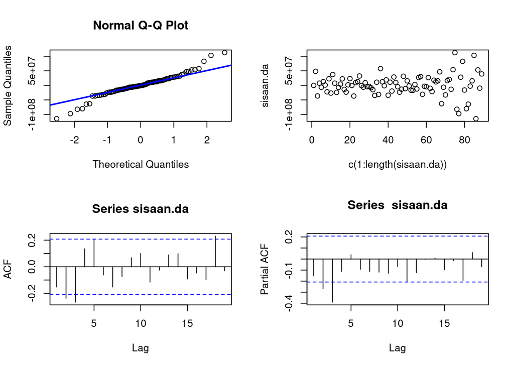

```r
#Eksplorasi
sisaan.da <- model_1$residuals
par(mfrow=c(2,2))
qqnorm(sisaan.da)
qqline(sisaan.da, col = "blue", lwd = 2)
plot(c(1:length(sisaan.da)),sisaan.da)
acf(sisaan.da)
pacf(sisaan.da)
```

```r
par(mfrow = c(1,1))
```

## sisaan cenderung tidak menyebar normal menurut uji kolmogorov smirnov

```r
ks.test(sisaan.da, "pnorm")
```

```
##
##  Exact one-sample Kolmogorov-Smirnov test
##
## data:  sisaan.da
## D = 0.52809, p-value < 2.2e-16
## alternative hypothesis: two-sided
```

## sisaan cenderung saling bebas

```r
Box.test(sisaan.da, type = "Ljung")
```

```
##
##  Box-Ljung test
##
## data:  sisaan.da
## X-squared = 2.1514, df = 1, p-value = 0.1424
```

## sisaan cenderung tidak homogen dalam ragam

```r
Box.test((sisaan.da)^2, type = "Ljung")
```

```
##
##  Box-Ljung test
##
## data:  (sisaan.da)^2
## X-squared = 19.565, df = 1, p-value = 9.723e-06
```

## sisaan cenderung memiliki rataan 0

```r
t.test(sisaan.da, mu = 0, conf.level = 0.95)
```

```
##
##  One Sample t-test
##
## data:  sisaan.da
## t = 0.13023, df = 88, p-value = 0.8967
## alternative hypothesis: true mean is not equal to 0
## 95 percent confidence interval:
##  -7130215  8130246
## sample estimates:
## mean of x
##  500015.8
```

## Overfitting

### dilakukan dengan menaikan orde dari ar(p) dan ma(q) dari Arima(2, 1, 0), sehingga model overfittingnya adalah Arima(3, 1, 0) dan Arima(2, 1, 1).

```r
model_overfit_1 <- Arima(mts_train_diff, order=c(3,1,0),method="ML")
summary(model_overfit_1)
```

```
## Series: mts_train_diff
## ARIMA(3,1,0)
##
## Coefficients:
##           ar1      ar2      ar3
##       -0.8306  -0.6837  -0.3897
## s.e.   0.0996   0.1112   0.1048
##
## sigma^2 = 1.17e+15:  log likelihood = -1650.52
## AIC=3309.05   AICc=3309.53   BIC=3318.96
##
## Training set error measures:
##                    ME     RMSE      MAE      MPE     MAPE      MASE       ACF1
## Training set 151373.1 33428284 23565744 17.69303 203.9918 0.7619068 -0.1195455
```

```r
lmtest::coeftest(model_overfit_1) #seluruh parameter signifikan
```

```
##
## z test of coefficients:
##
##      Estimate Std. Error z value  Pr(>|z|)
## ar1 -0.830612   0.099592 -8.3401 < 2.2e-16 ***
## ar2 -0.683674   0.111234 -6.1463 7.933e-10 ***
## ar3 -0.389651   0.104768 -3.7192 0.0001999 ***
## ---
## Signif. codes:  0 '***' 0.001 '**' 0.01 '*' 0.05 '.' 0.1 ' ' 1
```

```r
# AIC 3309.05
```

```r
model_overfit_2 <- Arima(mts_train_diff, order=c(2,1,1),method="ML")
summary(model_overfit_2)
```

```
## Series: mts_train_diff
## ARIMA(2,1,1)
##
## Coefficients:
##           ar1      ar2      ma1
##       -0.1419  -0.2072  -0.9860
## s.e.   0.1058   0.1061   0.0623
##
## sigma^2 = 9.088e+14:  log likelihood = -1640.93
## AIC=3289.87   AICc=3290.35   BIC=3299.77
##
## Training set error measures:
##                   ME     RMSE      MAE      MPE     MAPE      MASE        ACF1
## Training set 2967487 29461499 20037722 21.97651 169.8644 0.6478419 -0.02639883
```

```r
lmtest::coeftest(model_overfit_2) #tidak seluruh parameter signifikan
```

```
##
## z test of coefficients:
##
##      Estimate Std. Error  z value Pr(>|z|)
## ar1 -0.141949   0.105753  -1.3423  0.17951
## ar2 -0.207197   0.106138  -1.9522  0.05092 .
## ma1 -0.986009   0.062338 -15.8173  < 2e-16 ***
## ---
## Signif. codes:  0 '***' 0.001 '**' 0.01 '*' 0.05 '.' 0.1 ' ' 1
```

```r
# AIC 3289.87
```

### Model overfit Arima(3,1,0) semua parameternya siginifikan dan AIC nya lebih rendah dibandingkan Arima(2, 1, 0) sehingga akan dilanjutkan analisis sisaan dengan Arima(3, 1, 0)

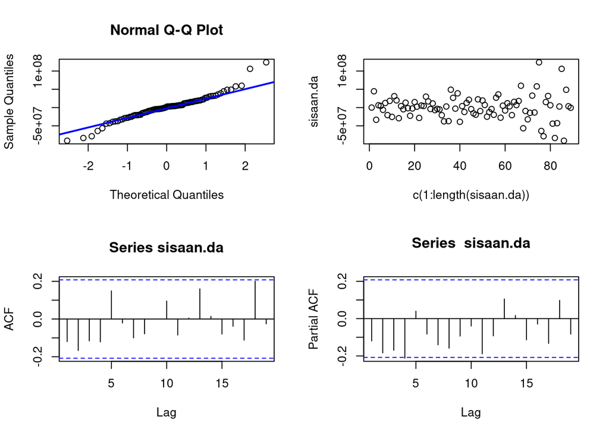

```r
#Eksplorasi
sisaan.da <- model_overfit_1$residuals
par(mfrow=c(2,2))
qqnorm(sisaan.da)
qqline(sisaan.da, col = "blue", lwd = 2)
plot(c(1:length(sisaan.da)),sisaan.da)
acf(sisaan.da)
pacf(sisaan.da)
```

```r
par(mfrow = c(1,1))
```

## Sisaan cenderung tidak menyebar normal menurut uji kolomogorov smirnov

```r
ks.test(sisaan.da, "pnorm")
```

```
##
##  Exact one-sample Kolmogorov-Smirnov test
##
## data:  sisaan.da
## D = 0.50562, p-value < 2.2e-16
## alternative hypothesis: two-sided
```

## Sisaan cenderung saling bebas

```r
Box.test(sisaan.da, type = "Ljung")
```

```
##
##  Box-Ljung test
##
## data:  sisaan.da
## X-squared = 1.3153, df = 1, p-value = 0.2514
```

## Sisaan cenderung memiliki ragam yang tidak homogen

```r
Box.test((sisaan.da)^2, type = "Ljung")
```

```
##
##  Box-Ljung test
##
## data:  (sisaan.da)^2
## X-squared = 14.266, df = 1, p-value = 0.0001587
```

## Sisaan cenderung memiliki nilai rataan 0

```r
t.test(sisaan.da, mu = 0, conf.level = 0.95)
```

```
##
##  One Sample t-test
##
## data:  sisaan.da
## t = 0.04248, df = 88, p-value = 0.9662
## alternative hypothesis: true mean is not equal to 0
## 95 percent confidence interval:
##  -6930196  7232943
## sample estimates:
## mean of x
##  151373.1
```

## Melakukan forecasting

```r
ramalan.da <- forecast::forecast(model_overfit_1, h = 26)
ramalan.da
```

```
##     Point Forecast     Lo 80    Hi 80      Lo 95     Hi 95
##  90    -28533404.4 -72369889 15303080  -95575522  38508713
##  91     10529289.8 -33931629 54990209  -57467818  78526398
##  92      3111993.9 -42010601 48234589  -65897060  72121048
##  93     -4278427.0 -51919298 43362444  -77138852  68581998
##  94     -8289663.3 -61185168 44605842  -89186357  72607031
##  95      2984911.9 -51103313 57073137  -79735890  85705714
##  96      -757827.3 -56336422 54820768  -85757953  84242299
##  97     -3794209.0 -61781373 54192955  -92477923  84889505
##  98     -3106491.1 -63522200 57309217  -95504344  89291361
##  99      -143461.7 -62041040 61754116  -94807638  94520715
## 100     -1891635.7 -65491554 61708283  -99159317  95376046
## 101     -2733295.9 -68286772 62820180 -102988686  97522094
## 102     -1993569.7 -69332602 65345463 -104979733 100992593
## 103     -1351396.7 -70231073 67528280 -106693772 103990978
## 104     -2062571.0 -72574310 68449168 -109900969 105775827
## 105     -2199132.7 -74373412 69975146 -112580167 108181902
## 106     -1849715.2 -75583960 71884530 -114616512 110917082
## 107     -1769472.2 -76993764 73454819 -116815098 113276154
## 108     -2021799.1 -78755729 74712131 -119376218 115332620
## 109     -2003224.2 -80226564 76220116 -121635499 117629051
## 110     -1877410.3 -81536873 77782052 -123706045 119951225
## 111     -1896292.6 -82963359 79170774 -125877672 122085087
## 112     -1973862.1 -84440525 80492801 -128095740 124148015
## 113     -1945546.1 -85786797 81895704 -130169674 126278581
## 114     -1908676.0 -87094220 83276869 -132188724 128371372
## 115     -1928434.6 -88439160 84582290 -134235171 130378302
```

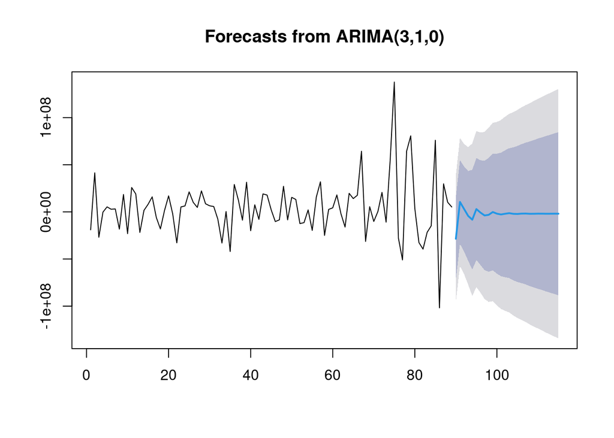

```r
data.ramalan.da <- ramalan.da$mean
plot(ramalan.da)
```

## Transformasi hasil dan plotting aktual dengan forecasting

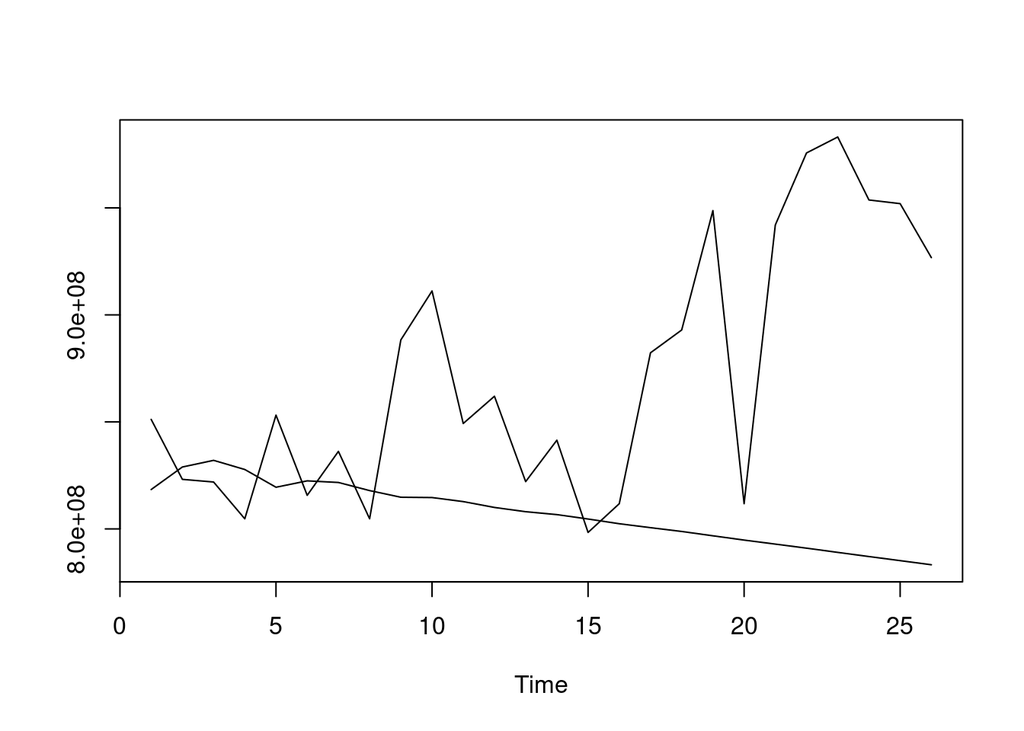

```r
pt_1 <- mts_train[90] #nilai akhir data latih
hasil.forc.Diff <- data.ramalan.da
hasil <- diffinv(hasil.forc.Diff, differences = 1) + pt_1
#has.1 sama hasilnta dengan: cumsum(c(pt_1,hasil.forc.Diff))
ts.plot(mts_test,ts(hasil[-1]))
```

## Didapatkan MAPE pada data testing adalah 7 % sehingga cukup bagus karena dibawah 10 %

```r
perbandingan.da<-matrix(data=c(head(mts_test, n=26), hasil[-1]),
                     nrow = 26, ncol = 2)
colnames(perbandingan.da)<-c("Aktual","Hasil Forecast")
perbandingan.da
```

```
##          Aktual Hasil Forecast
##  [1,] 851171127      818394907
##  [2,] 823153670      828924196
##  [3,] 821914135      832036190
##  [4,] 804724763      827757763
##  [5,] 853152517      819468100
##  [6,] 815691802      822453012
##  [7,] 836217092      821695185
##  [8,] 804724763      817900976
##  [9,] 888291980      814794484
## [10,] 911168929      814651023
## [11,] 849254440      812759387
## [12,] 861986434      810026091
## [13,] 822094437      808032521
## [14,] 841443321      806681125
## [15,] 798353629      804618554
## [16,] 811785940      802419421
## [17,] 882282860      800569706
## [18,] 892945377      798800234
## [19,] 948727146      796778435
## [20,] 811785940      794775210
## [21,] 942011616      792897800
## [22,] 975666361      791001508
## [23,] 983118692      789027646
## [24,] 953689043      787082099
## [25,] 951975640      785173423
## [26,] 926756485      783244989
```

```r
accuracy(ts(hasil[-1]), head(mts_test, n=26))
```

```
##                ME     RMSE      MAE      MPE     MAPE
## Test set 64697083 94602364 69706924 6.944972 7.563875
```